# Risk Factor Analysis

## Outcome Variable

**Outcome Variable:** sstunted

## Predictor Variables

**Intervention Variable:** exclfeed36

**Adjustment Set:**

- arm
- sex
- W_mage
- meducyrs
- feducyrs
- hhwealth_quart
- hfoodsec
- W_mhtcm
- vagbrth
- W_gagebrth
- W_birthwt
- W_birthlen
- W_nrooms
- W_nchldlt5
- month
- brthmon
- W_parity
- impfloor
- impsan
- safeh20
- delta_W_mage
- delta_meducyrs
- delta_feducyrs
- delta_hhwealth_quart
- delta_hfoodsec
- delta_W_mhtcm
- delta_vagbrth
- delta_W_gagebrth
- delta_W_birthwt
- delta_W_birthlen
- delta_W_nrooms
- delta_W_nchldlt5
- delta_month
- delta_brthmon
- delta_W_parity
- delta_impfloor
- delta_impsan
- delta_safeh20

## Stratifying Variables

The analysis was stratified on these variable(s):

- agecat
- studyid
- country

## Data Summary

| agecat | studyid | country | exclfeed36 | sstunted | n_cell | n |
| --- | --- | --- | --- | --- | --- | --- |
| Birth | ki0047075b-MAL-ED | BANGLADESH | 0 | 0 | 175 | 243 |
| Birth | ki0047075b-MAL-ED | BANGLADESH | 0 | 1 | 6 | 243 |
| Birth | ki0047075b-MAL-ED | BANGLADESH | 1 | 0 | 61 | 243 |
| Birth | ki0047075b-MAL-ED | BANGLADESH | 1 | 1 | 1 | 243 |
| Birth | ki0047075b-MAL-ED | BRAZIL | 0 | 0 | 165 | 185 |
| Birth | ki0047075b-MAL-ED | BRAZIL | 0 | 1 | 7 | 185 |
| Birth | ki0047075b-MAL-ED | BRAZIL | 1 | 0 | 12 | 185 |
| Birth | ki0047075b-MAL-ED | BRAZIL | 1 | 1 | 1 | 185 |
| Birth | ki0047075b-MAL-ED | INDIA | 0 | 0 | 186 | 198 |
| Birth | ki0047075b-MAL-ED | INDIA | 0 | 1 | 7 | 198 |
| Birth | ki0047075b-MAL-ED | INDIA | 1 | 0 | 5 | 198 |
| Birth | ki0047075b-MAL-ED | INDIA | 1 | 1 | 0 | 198 |
| Birth | ki0047075b-MAL-ED | NEPAL | 0 | 0 | 155 | 172 |
| Birth | ki0047075b-MAL-ED | NEPAL | 0 | 1 | 6 | 172 |
| Birth | ki0047075b-MAL-ED | NEPAL | 1 | 0 | 11 | 172 |
| Birth | ki0047075b-MAL-ED | NEPAL | 1 | 1 | 0 | 172 |
| Birth | ki0047075b-MAL-ED | PERU | 0 | 0 | 253 | 273 |
| Birth | ki0047075b-MAL-ED | PERU | 0 | 1 | 5 | 273 |
| Birth | ki0047075b-MAL-ED | PERU | 1 | 0 | 14 | 273 |
| Birth | ki0047075b-MAL-ED | PERU | 1 | 1 | 1 | 273 |
| Birth | ki0047075b-MAL-ED | SOUTH AFRICA | 0 | 0 | 235 | 236 |
| Birth | ki0047075b-MAL-ED | SOUTH AFRICA | 0 | 1 | 1 | 236 |
| Birth | ki0047075b-MAL-ED | SOUTH AFRICA | 1 | 0 | 0 | 236 |
| Birth | ki0047075b-MAL-ED | SOUTH AFRICA | 1 | 1 | 0 | 236 |
| Birth | ki0047075b-MAL-ED | TANZANIA, UNITED REPUBLIC OF | 0 | 0 | 114 | 121 |
| Birth | ki0047075b-MAL-ED | TANZANIA, UNITED REPUBLIC OF | 0 | 1 | 6 | 121 |
| Birth | ki0047075b-MAL-ED | TANZANIA, UNITED REPUBLIC OF | 1 | 0 | 1 | 121 |
| Birth | ki0047075b-MAL-ED | TANZANIA, UNITED REPUBLIC OF | 1 | 1 | 0 | 121 |
| Birth | ki1000108-CMC-V-BCS-2002 | INDIA | 0 | 0 | 0 | 3 |
| Birth | ki1000108-CMC-V-BCS-2002 | INDIA | 0 | 1 | 0 | 3 |

[output cut: 150 more lines]

The following strata were considered:

- agecat: 24 months, studyid: ki0047075b-MAL-ED, country: BANGLADESH
- agecat: 24 months, studyid: ki0047075b-MAL-ED, country: BRAZIL
- agecat: 24 months, studyid: ki0047075b-MAL-ED, country: INDIA
- agecat: 24 months, studyid: ki0047075b-MAL-ED, country: NEPAL
- agecat: 24 months, studyid: ki0047075b-MAL-ED, country: PERU
- agecat: 24 months, studyid: ki0047075b-MAL-ED, country: SOUTH AFRICA
- agecat: 24 months, studyid: ki0047075b-MAL-ED, country: TANZANIA, UNITED REPUBLIC OF
- agecat: 24 months, studyid: ki1000108-CMC-V-BCS-2002, country: INDIA
- agecat: 24 months, studyid: ki1000108-IRC, country: INDIA
- agecat: 24 months, studyid: ki1017093b-PROVIDE, country: BANGLADESH
- agecat: 24 months, studyid: ki1101329-Keneba, country: GAMBIA
- agecat: 24 months, studyid: ki1113344-GMS-Nepal, country: NEPAL
- agecat: 24 months, studyid: ki1148112-LCNI-5, country: MALAWI
- agecat: 24 months, studyid: kiGH5241-JiVitA-3, country: BANGLADESH
- agecat: 24 months, studyid: kiGH5241-JiVitA-4, country: BANGLADESH
- agecat: 6 months, studyid: ki0047075b-MAL-ED, country: BANGLADESH
- agecat: 6 months, studyid: ki0047075b-MAL-ED, country: BRAZIL
- agecat: 6 months, studyid: ki0047075b-MAL-ED, country: INDIA
- agecat: 6 months, studyid: ki0047075b-MAL-ED, country: NEPAL
- agecat: 6 months, studyid: ki0047075b-MAL-ED, country: PERU
- agecat: 6 months, studyid: ki0047075b-MAL-ED, country: SOUTH AFRICA
- agecat: 6 months, studyid: ki0047075b-MAL-ED, country: TANZANIA, UNITED REPUBLIC OF
- agecat: 6 months, studyid: ki1000108-CMC-V-BCS-2002, country: INDIA
- agecat: 6 months, studyid: ki1000108-IRC, country: INDIA
- agecat: 6 months, studyid: ki1000109-EE, country: PAKISTAN
- agecat: 6 months, studyid: ki1000304b-SAS-FoodSuppl, country: INDIA
- agecat: 6 months, studyid: ki1017093b-PROVIDE, country: BANGLADESH
- agecat: 6 months, studyid: ki1101329-Keneba, country: GAMBIA
- agecat: 6 months, studyid: ki1113344-GMS-Nepal, country: NEPAL
- agecat: 6 months, studyid: ki1148112-LCNI-5, country: MALAWI
- agecat: 6 months, studyid: kiGH5241-JiVitA-3, country: BANGLADESH
- agecat: 6 months, studyid: kiGH5241-JiVitA-4, country: BANGLADESH
- agecat: Birth, studyid: ki0047075b-MAL-ED, country: BANGLADESH
- agecat: Birth, studyid: ki0047075b-MAL-ED, country: BRAZIL
- agecat: Birth, studyid: ki0047075b-MAL-ED, country: INDIA
- agecat: Birth, studyid: ki0047075b-MAL-ED, country: NEPAL
- agecat: Birth, studyid: ki0047075b-MAL-ED, country: PERU
- agecat: Birth, studyid: ki0047075b-MAL-ED, country: SOUTH AFRICA
- agecat: Birth, studyid: ki0047075b-MAL-ED, country: TANZANIA, UNITED REPUBLIC OF
- agecat: Birth, studyid: ki1000108-CMC-V-BCS-2002, country: INDIA
- agecat: Birth, studyid: ki1000108-IRC, country: INDIA
- agecat: Birth, studyid: ki1000109-EE, country: PAKISTAN
- agecat: Birth, studyid: ki1101329-Keneba, country: GAMBIA
- agecat: Birth, studyid: kiGH5241-JiVitA-3, country: BANGLADESH
- agecat: Birth, studyid: kiGH5241-JiVitA-4, country: BANGLADESH

### Dropped Strata

Some strata were dropped due to rare outcomes:

- agecat: Birth, studyid: ki0047075b-MAL-ED, country: BANGLADESH
- agecat: Birth, studyid: ki0047075b-MAL-ED, country: BRAZIL
- agecat: Birth, studyid: ki0047075b-MAL-ED, country: INDIA
- agecat: Birth, studyid: ki0047075b-MAL-ED, country: NEPAL
- agecat: Birth, studyid: ki0047075b-MAL-ED, country: PERU
- agecat: Birth, studyid: ki0047075b-MAL-ED, country: SOUTH AFRICA
- agecat: Birth, studyid: ki0047075b-MAL-ED, country: TANZANIA, UNITED REPUBLIC OF
- agecat: Birth, studyid: ki1000108-CMC-V-BCS-2002, country: INDIA
- agecat: Birth, studyid: ki1000108-IRC, country: INDIA
- agecat: Birth, studyid: ki1000109-EE, country: PAKISTAN
- agecat: 6 months, studyid: ki0047075b-MAL-ED, country: BANGLADESH
- agecat: 6 months, studyid: ki0047075b-MAL-ED, country: BRAZIL
- agecat: 6 months, studyid: ki0047075b-MAL-ED, country: INDIA
- agecat: 6 months, studyid: ki0047075b-MAL-ED, country: NEPAL
- agecat: 6 months, studyid: ki0047075b-MAL-ED, country: PERU
- agecat: 6 months, studyid: ki0047075b-MAL-ED, country: SOUTH AFRICA
- agecat: 6 months, studyid: ki0047075b-MAL-ED, country: TANZANIA, UNITED REPUBLIC OF
- agecat: 6 months, studyid: ki1000108-CMC-V-BCS-2002, country: INDIA
- agecat: 6 months, studyid: ki1000108-IRC, country: INDIA
- agecat: 6 months, studyid: ki1000304b-SAS-FoodSuppl, country: INDIA
- agecat: 6 months, studyid: ki1017093b-PROVIDE, country: BANGLADESH
- agecat: 6 months, studyid: ki1148112-LCNI-5, country: MALAWI
- agecat: 24 months, studyid: ki0047075b-MAL-ED, country: BRAZIL
- agecat: 24 months, studyid: ki0047075b-MAL-ED, country: INDIA
- agecat: 24 months, studyid: ki0047075b-MAL-ED, country: NEPAL
- agecat: 24 months, studyid: ki0047075b-MAL-ED, country: PERU
- agecat: 24 months, studyid: ki0047075b-MAL-ED, country: SOUTH AFRICA
- agecat: 24 months, studyid: ki0047075b-MAL-ED, country: TANZANIA, UNITED REPUBLIC OF
- agecat: 24 months, studyid: ki1000108-CMC-V-BCS-2002, country: INDIA
- agecat: 24 months, studyid: ki1000108-IRC, country: INDIA
- agecat: 24 months, studyid: ki1148112-LCNI-5, country: MALAWI

## Methods Detail

We’re interested in the causal parameters $E[Y_a]$ for all values of $a \in \mathcal{A}$. These parameters represent the mean outcome if, possibly contrary to fact, we intervened to set all units to have $A=a$. Under the randomization and positivity assumptions, these are identified by the statistical parameters $\psi_a=E_W[E_{Y|A,W}(Y|A=a,W)]$. In addition, we’re interested in the mean of $Y$, $E[Y]$ under no intervention (the observed mean). We will estimate these parameters by using SuperLearner to fit the relevant likelihood factors – $E_{Y|A,W}(Y|A=a,W)$ and $p(A=a|W)$, and then updating our likelihood fit using a joint TMLE.

For unadjusted analyses ($W=\{\}$), initial likelihoods were estimated using Lrnr_glm to estimate the simple $E(Y|A)$ and Lrnr_mean to estimate $p(A)$. For adjusted analyses, a small library containing Lrnr_glmnet, Lrnr_xgboost, and Lrnr_mean was used.

Having estimated these parameters, we will then use the delta method to estimate relative risks and attributable risks relative to a prespecified baseline level of $A$.

# Results Detail

## Results Plots

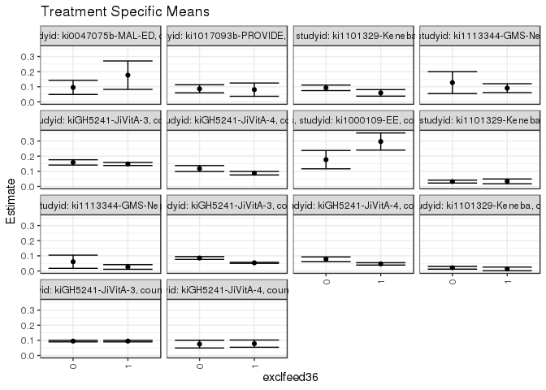

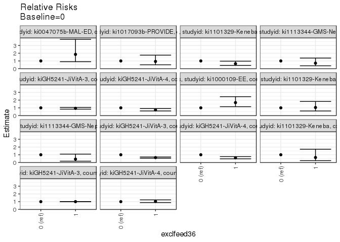

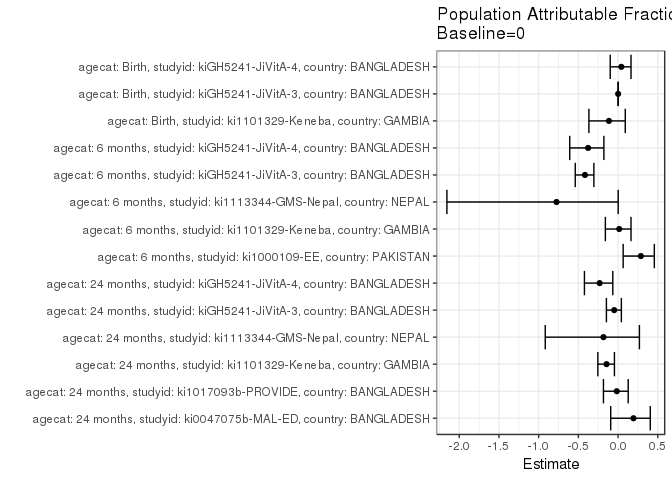

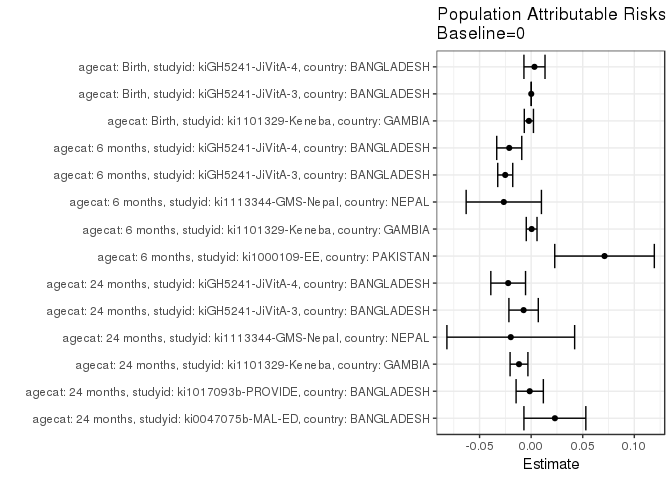

## Results Table

### Parameter: TSM

| agecat | studyid | country | intervention_level | baseline_level | estimate | ci_lower | ci_upper |
| --- | --- | --- | --- | --- | --- | --- | --- |
| Birth | ki1101329-Keneba | GAMBIA | 0 | NA | 0.0213723 | 0.0118618 | 0.0308829 |
| Birth | ki1101329-Keneba | GAMBIA | 1 | NA | 0.0137741 | 0.0017794 | 0.0257688 |
| Birth | kiGH5241-JiVitA-3 | BANGLADESH | 0 | NA | 0.0950583 | 0.0899589 | 0.1001577 |
| Birth | kiGH5241-JiVitA-3 | BANGLADESH | 1 | NA | 0.0950849 | 0.0899871 | 0.1001827 |
| Birth | kiGH5241-JiVitA-4 | BANGLADESH | 0 | NA | 0.0751814 | 0.0494789 | 0.1008838 |
| Birth | kiGH5241-JiVitA-4 | BANGLADESH | 1 | NA | 0.0782465 | 0.0543079 | 0.1021851 |
| 6 months | ki1000109-EE | PAKISTAN | 0 | NA | 0.1768240 | 0.1163381 | 0.2373100 |
| 6 months | ki1000109-EE | PAKISTAN | 1 | NA | 0.2966406 | 0.2398007 | 0.3534804 |
| 6 months | ki1101329-Keneba | GAMBIA | 0 | NA | 0.0319258 | 0.0223058 | 0.0415458 |
| 6 months | ki1101329-Keneba | GAMBIA | 1 | NA | 0.0333576 | 0.0176657 | 0.0490495 |
| 6 months | ki1113344-GMS-Nepal | NEPAL | 0 | NA | 0.0607407 | 0.0171210 | 0.1043604 |
| 6 months | ki1113344-GMS-Nepal | NEPAL | 1 | NA | 0.0261941 | 0.0109448 | 0.0414435 |
| 6 months | kiGH5241-JiVitA-3 | BANGLADESH | 0 | NA | 0.0853856 | 0.0761832 | 0.0945879 |
| 6 months | kiGH5241-JiVitA-3 | BANGLADESH | 1 | NA | 0.0538233 | 0.0497748 | 0.0578718 |
| 6 months | kiGH5241-JiVitA-4 | BANGLADESH | 0 | NA | 0.0775789 | 0.0622025 | 0.0929552 |
| 6 months | kiGH5241-JiVitA-4 | BANGLADESH | 1 | NA | 0.0466304 | 0.0388176 | 0.0544432 |
| 24 months | ki0047075b-MAL-ED | BANGLADESH | 0 | NA | 0.0954775 | 0.0490283 | 0.1419267 |
| 24 months | ki0047075b-MAL-ED | BANGLADESH | 1 | NA | 0.1764551 | 0.0825008 | 0.2704094 |
| 24 months | ki1017093b-PROVIDE | BANGLADESH | 0 | NA | 0.0864576 | 0.0598216 | 0.1130936 |
| 24 months | ki1017093b-PROVIDE | BANGLADESH | 1 | NA | 0.0809410 | 0.0369846 | 0.1248974 |
| 24 months | ki1101329-Keneba | GAMBIA | 0 | NA | 0.0928451 | 0.0746240 | 0.1110661 |
| 24 months | ki1101329-Keneba | GAMBIA | 1 | NA | 0.0594905 | 0.0379433 | 0.0810377 |
| 24 months | ki1113344-GMS-Nepal | NEPAL | 0 | NA | 0.1272116 | 0.0550994 | 0.1993238 |
| 24 months | ki1113344-GMS-Nepal | NEPAL | 1 | NA | 0.0907064 | 0.0612974 | 0.1201154 |
| 24 months | kiGH5241-JiVitA-3 | BANGLADESH | 0 | NA | 0.1586727 | 0.1411561 | 0.1761893 |
| 24 months | kiGH5241-JiVitA-3 | BANGLADESH | 1 | NA | 0.1484271 | 0.1382764 | 0.1585777 |
| 24 months | kiGH5241-JiVitA-4 | BANGLADESH | 0 | NA | 0.1182132 | 0.0985682 | 0.1378582 |
| 24 months | kiGH5241-JiVitA-4 | BANGLADESH | 1 | NA | 0.0873276 | 0.0757421 | 0.0989132 |

### Parameter: E(Y)

| agecat | studyid | country | intervention_level | baseline_level | estimate | ci_lower | ci_upper |
| --- | --- | --- | --- | --- | --- | --- | --- |
| Birth | ki1101329-Keneba | GAMBIA | NA | NA | 0.0191693 | 0.0115710 | 0.0267677 |
| Birth | kiGH5241-JiVitA-3 | BANGLADESH | NA | NA | 0.0951527 | 0.0900508 | 0.1002546 |
| Birth | kiGH5241-JiVitA-4 | BANGLADESH | NA | NA | 0.0784044 | 0.0544827 | 0.1023261 |
| 6 months | ki1000109-EE | PAKISTAN | NA | NA | 0.2479564 | 0.2037162 | 0.2921966 |
| 6 months | ki1101329-Keneba | GAMBIA | NA | NA | 0.0324022 | 0.0241972 | 0.0406072 |
| 6 months | ki1113344-GMS-Nepal | NEPAL | NA | NA | 0.0342205 | 0.0186698 | 0.0497713 |
| 6 months | kiGH5241-JiVitA-3 | BANGLADESH | NA | NA | 0.0602617 | 0.0561000 | 0.0644233 |
| 6 months | kiGH5241-JiVitA-4 | BANGLADESH | NA | NA | 0.0563414 | 0.0484727 | 0.0642101 |
| 24 months | ki0047075b-MAL-ED | BANGLADESH | NA | NA | 0.1184834 | 0.0747732 | 0.1621936 |
| 24 months | ki1017093b-PROVIDE | BANGLADESH | NA | NA | 0.0850694 | 0.0622663 | 0.1078726 |
| 24 months | ki1101329-Keneba | GAMBIA | NA | NA | 0.0810617 | 0.0667291 | 0.0953942 |
| 24 months | ki1113344-GMS-Nepal | NEPAL | NA | NA | 0.1074561 | 0.0790002 | 0.1359121 |
| 24 months | kiGH5241-JiVitA-3 | BANGLADESH | NA | NA | 0.1513522 | 0.1415495 | 0.1611548 |
| 24 months | kiGH5241-JiVitA-4 | BANGLADESH | NA | NA | 0.0959483 | 0.0853397 | 0.1065568 |

### Parameter: RR

| agecat | studyid | country | intervention_level | baseline_level | estimate | ci_lower | ci_upper |
| --- | --- | --- | --- | --- | --- | --- | --- |
| Birth | ki1101329-Keneba | GAMBIA | 0 | 0 | 1.0000000 | 1.0000000 | 1.0000000 |
| Birth | ki1101329-Keneba | GAMBIA | 1 | 0 | 0.6444831 | 0.2423845 | 1.7136347 |
| Birth | kiGH5241-JiVitA-3 | BANGLADESH | 0 | 0 | 1.0000000 | 1.0000000 | 1.0000000 |
| Birth | kiGH5241-JiVitA-3 | BANGLADESH | 1 | 0 | 1.0002798 | 0.9996708 | 1.0008892 |
| Birth | kiGH5241-JiVitA-4 | BANGLADESH | 0 | 0 | 1.0000000 | 1.0000000 | 1.0000000 |
| Birth | kiGH5241-JiVitA-4 | BANGLADESH | 1 | 0 | 1.0407692 | 0.8798556 | 1.2311117 |
| 6 months | ki1000109-EE | PAKISTAN | 0 | 0 | 1.0000000 | 1.0000000 | 1.0000000 |
| 6 months | ki1000109-EE | PAKISTAN | 1 | 0 | 1.6776034 | 1.1520668 | 2.4428733 |
| 6 months | ki1101329-Keneba | GAMBIA | 0 | 0 | 1.0000000 | 1.0000000 | 1.0000000 |
| 6 months | ki1101329-Keneba | GAMBIA | 1 | 0 | 1.0448497 | 0.5976887 | 1.8265544 |
| 6 months | ki1113344-GMS-Nepal | NEPAL | 0 | 0 | 1.0000000 | 1.0000000 | 1.0000000 |
| 6 months | ki1113344-GMS-Nepal | NEPAL | 1 | 0 | 0.4312452 | 0.1714204 | 1.0848910 |
| 6 months | kiGH5241-JiVitA-3 | BANGLADESH | 0 | 0 | 1.0000000 | 1.0000000 | 1.0000000 |
| 6 months | kiGH5241-JiVitA-3 | BANGLADESH | 1 | 0 | 0.6303556 | 0.5582126 | 0.7118222 |
| 6 months | kiGH5241-JiVitA-4 | BANGLADESH | 0 | 0 | 1.0000000 | 1.0000000 | 1.0000000 |
| 6 months | kiGH5241-JiVitA-4 | BANGLADESH | 1 | 0 | 0.6010704 | 0.4735998 | 0.7628502 |
| 24 months | ki0047075b-MAL-ED | BANGLADESH | 0 | 0 | 1.0000000 | 1.0000000 | 1.0000000 |
| 24 months | ki0047075b-MAL-ED | BANGLADESH | 1 | 0 | 1.8481322 | 0.9010931 | 3.7904988 |
| 24 months | ki1017093b-PROVIDE | BANGLADESH | 0 | 0 | 1.0000000 | 1.0000000 | 1.0000000 |
| 24 months | ki1017093b-PROVIDE | BANGLADESH | 1 | 0 | 0.9361933 | 0.5014897 | 1.7477086 |
| 24 months | ki1101329-Keneba | GAMBIA | 0 | 0 | 1.0000000 | 1.0000000 | 1.0000000 |
| 24 months | ki1101329-Keneba | GAMBIA | 1 | 0 | 0.6407503 | 0.4245976 | 0.9669413 |
| 24 months | ki1113344-GMS-Nepal | NEPAL | 0 | 0 | 1.0000000 | 1.0000000 | 1.0000000 |
| 24 months | ki1113344-GMS-Nepal | NEPAL | 1 | 0 | 0.7130357 | 0.3712819 | 1.3693637 |
| 24 months | kiGH5241-JiVitA-3 | BANGLADESH | 0 | 0 | 1.0000000 | 1.0000000 | 1.0000000 |
| 24 months | kiGH5241-JiVitA-3 | BANGLADESH | 1 | 0 | 0.9354293 | 0.8317174 | 1.0520736 |
| 24 months | kiGH5241-JiVitA-4 | BANGLADESH | 0 | 0 | 1.0000000 | 1.0000000 | 1.0000000 |
| 24 months | kiGH5241-JiVitA-4 | BANGLADESH | 1 | 0 | 0.7387298 | 0.6012199 | 0.9076907 |

### Parameter: PAR

| agecat | studyid | country | intervention_level | baseline_level | estimate | ci_lower | ci_upper |
| --- | --- | --- | --- | --- | --- | --- | --- |
| Birth | ki1101329-Keneba | GAMBIA | 0 | NA | -0.0022030 | -0.0066453 | 0.0022393 |
| Birth | kiGH5241-JiVitA-3 | BANGLADESH | 0 | NA | 0.0000944 | 0.0000518 | 0.0001371 |
| Birth | kiGH5241-JiVitA-4 | BANGLADESH | 0 | NA | 0.0032230 | -0.0069951 | 0.0134412 |
| 6 months | ki1000109-EE | PAKISTAN | 0 | NA | 0.0711324 | 0.0228666 | 0.1193982 |
| 6 months | ki1101329-Keneba | GAMBIA | 0 | NA | 0.0004765 | -0.0047352 | 0.0056881 |
| 6 months | ki1113344-GMS-Nepal | NEPAL | 0 | NA | -0.0265202 | -0.0630061 | 0.0099658 |
| 6 months | kiGH5241-JiVitA-3 | BANGLADESH | 0 | NA | -0.0251239 | -0.0323944 | -0.0178534 |
| 6 months | kiGH5241-JiVitA-4 | BANGLADESH | 0 | NA | -0.0212375 | -0.0333678 | -0.0091072 |
| 24 months | ki0047075b-MAL-ED | BANGLADESH | 0 | NA | 0.0230059 | -0.0070005 | 0.0530123 |
| 24 months | ki1017093b-PROVIDE | BANGLADESH | 0 | NA | -0.0013882 | -0.0146000 | 0.0118237 |
| 24 months | ki1101329-Keneba | GAMBIA | 0 | NA | -0.0117834 | -0.0204244 | -0.0031424 |
| 24 months | ki1113344-GMS-Nepal | NEPAL | 0 | NA | -0.0197554 | -0.0816651 | 0.0421543 |
| 24 months | kiGH5241-JiVitA-3 | BANGLADESH | 0 | NA | -0.0073205 | -0.0215615 | 0.0069205 |
| 24 months | kiGH5241-JiVitA-4 | BANGLADESH | 0 | NA | -0.0222649 | -0.0390908 | -0.0054390 |

### Parameter: PAF

| agecat | studyid | country | intervention_level | baseline_level | estimate | ci_lower | ci_upper |
| --- | --- | --- | --- | --- | --- | --- | --- |
| Birth | ki1101329-Keneba | GAMBIA | 0 | NA | -0.1149231 | -0.3671976 | 0.0908018 |
| Birth | kiGH5241-JiVitA-3 | BANGLADESH | 0 | NA | 0.0009925 | 0.0005447 | 0.0014401 |
| Birth | kiGH5241-JiVitA-4 | BANGLADESH | 0 | NA | 0.0411078 | -0.0987103 | 0.1631331 |
| 6 months | ki1000109-EE | PAKISTAN | 0 | NA | 0.2868746 | 0.0641152 | 0.4566128 |
| 6 months | ki1101329-Keneba | GAMBIA | 0 | NA | 0.0147044 | -0.1599609 | 0.1630689 |
| 6 months | ki1113344-GMS-Nepal | NEPAL | 0 | NA | -0.7749786 | -2.1552507 | 0.0014901 |
| 6 months | kiGH5241-JiVitA-3 | BANGLADESH | 0 | NA | -0.4169135 | -0.5390241 | -0.3044916 |
| 6 months | kiGH5241-JiVitA-4 | BANGLADESH | 0 | NA | -0.3769428 | -0.6086843 | -0.1785852 |
| 24 months | ki0047075b-MAL-ED | BANGLADESH | 0 | NA | 0.1941696 | -0.0927232 | 0.4057392 |
| 24 months | ki1017093b-PROVIDE | BANGLADESH | 0 | NA | -0.0163179 | -0.1840641 | 0.1276638 |
| 24 months | ki1101329-Keneba | GAMBIA | 0 | NA | -0.1453632 | -0.2545422 | -0.0456857 |
| 24 months | ki1113344-GMS-Nepal | NEPAL | 0 | NA | -0.1838464 | -0.9167699 | 0.2688260 |
| 24 months | kiGH5241-JiVitA-3 | BANGLADESH | 0 | NA | -0.0483673 | -0.1467707 | 0.0415922 |
| 24 months | kiGH5241-JiVitA-4 | BANGLADESH | 0 | NA | -0.2320512 | -0.4234607 | -0.0663801 |